# Course Project 1

Robson Cruz

20/01/2021

## Introduction

This assignment makes use of data from a personal activity monitoring device. This device collects data at 5 minute intervals through out the day. The data consists of two months of data from an anonymous individual collected during the months of October and November, 2012 and include the number of steps taken in 5 minute intervals each day.

## Loading and preprocessing the data

```r
## Load libraries
library(ggplot2)
library(dplyr)
library(lubridate)
library(tidyr)
## 1. Load data
activity <- read.csv(file = "./data/activity.csv",
                     header = TRUE,
                     dec = ".",
                     sep = ",")

## 2. Processing
activity <- activity %>%
        mutate(date = as.Date(date, format = "%Y-%m-%d"),
               day = mday(date))

as_tibble(activity)
```

```
## # A tibble: 17,568 x 4
##    steps date       interval   day
##    <int> <date>        <int> <int>
##  1    NA 2012-10-01        0     1
##  2    NA 2012-10-01        5     1
##  3    NA 2012-10-01       10     1
##  4    NA 2012-10-01       15     1
##  5    NA 2012-10-01       20     1
##  6    NA 2012-10-01       25     1
##  7    NA 2012-10-01       30     1
##  8    NA 2012-10-01       35     1
##  9    NA 2012-10-01       40     1
## 10    NA 2012-10-01       45     1
## # ... with 17,558 more rows
```

## What is mean total number of steps taken per day?

```r
activity %>%
        filter(!is.na(steps)) %>%
        group_by(day) %>%
        summarize(avg_steps = mean(steps), Total_steps = n())
```

```
## # A tibble: 30 x 3
##      day avg_steps Total_steps
##    <int>     <dbl>       <int>
##  1     2      18.6         576
##  2     3      38.1         576
##  3     4      42.1         288
##  4     5      41.2         576
##  5     6      41.2         576
##  6     7      41.5         576
##  7     8      11.2         288
##  8     9      44.5         288
##  9    10      34.4         288
## 10    11      39.8         576
## # ... with 20 more rows
```

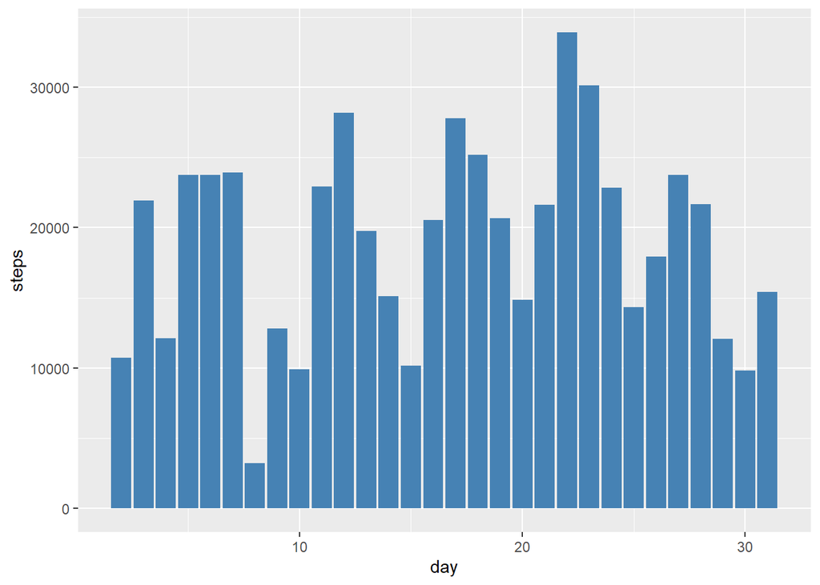

```r
activity %>%
        filter(!is.na(steps)) %>%
        group_by(day, steps) %>%
        ggplot(aes(x = day, y = steps)) +
        geom_bar(stat = "identity", fill = "steelblue")
```

```r
activity %>%
        filter(!is.na(steps)) %>%
        group_by(day, steps) %>%
        summarize(avg_steps = mean(steps), median = median(steps))
```

```
## # A tibble: 3,007 x 4
## # Groups:   day [30]
##      day steps avg_steps median
##    <int> <int>     <dbl>  <dbl>
##  1     2     0         0      0
##  2     2     6         6      6
##  3     2     8         8      8
##  4     2     9         9      9
##  5     2    10        10     10
##  6     2    11        11     11
##  7     2    14        14     14
##  8     2    15        15     15
##  9     2    16        16     16
## 10     2    17        17     17
## # ... with 2,997 more rows
```

## What is the average daily activity pattern?

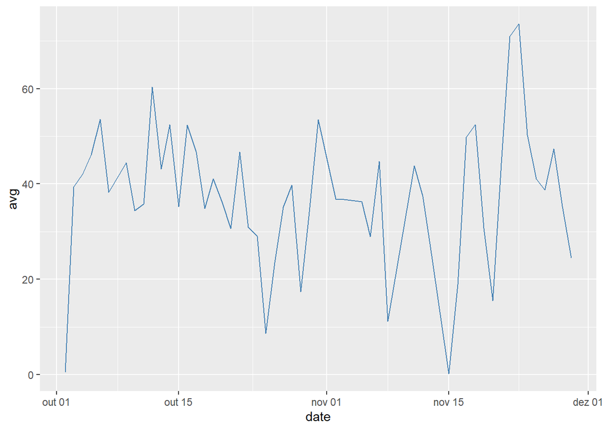

```r
activity %>%
        filter(!is.na(steps), !is.na(date)) %>%
        group_by(date) %>%
        summarize(avg = mean(steps)) %>%
        ggplot(aes(x = date, y = avg)) +
        geom_line(color="steelblue") +
        scale_x_date(date_labels = "%b %d")
```

```r
activity %>%
        mutate(avg = mean(interval, na.rm = TRUE)) %>%
        summarize(max = max(avg, na.rm = TRUE)) %>%
        print()
```

```
##      max
## 1 1177.5
```

## Imputing missing values

1. Calculate and report the total number of missing values in the dataset

```r
activity %>%
        filter_all(any_vars(is.na(.))) %>%
        group_by(steps) %>%
        summarize(n = n())
```

```
## # A tibble: 1 x 2
##   steps     n
##   <int> <int>
## 1    NA  2304
```

2. Devise a strategy for filling in all of the missing values in the dataset. The strategy does not need to be sophisticated. For example, you could use the mean/median for that day, or the mean for that 5-minute interval, etc.

```r
activity %>%
        replace_na(list(steps = 37.38)) %>%
        as_tibble()
```

```
## # A tibble: 17,568 x 4
##    steps date       interval   day
##    <dbl> <date>        <int> <int>
##  1  37.4 2012-10-01        0     1
##  2  37.4 2012-10-01        5     1
##  3  37.4 2012-10-01       10     1
##  4  37.4 2012-10-01       15     1
##  5  37.4 2012-10-01       20     1
##  6  37.4 2012-10-01       25     1
##  7  37.4 2012-10-01       30     1
##  8  37.4 2012-10-01       35     1
##  9  37.4 2012-10-01       40     1
## 10  37.4 2012-10-01       45     1
## # ... with 17,558 more rows
```

3. Create a new dataset that is equal to the original dataset but with the missing data filled in.

```r
no_NA <- activity %>%
        replace_na(list(steps = 37.38)) %>%
        as_tibble()
```

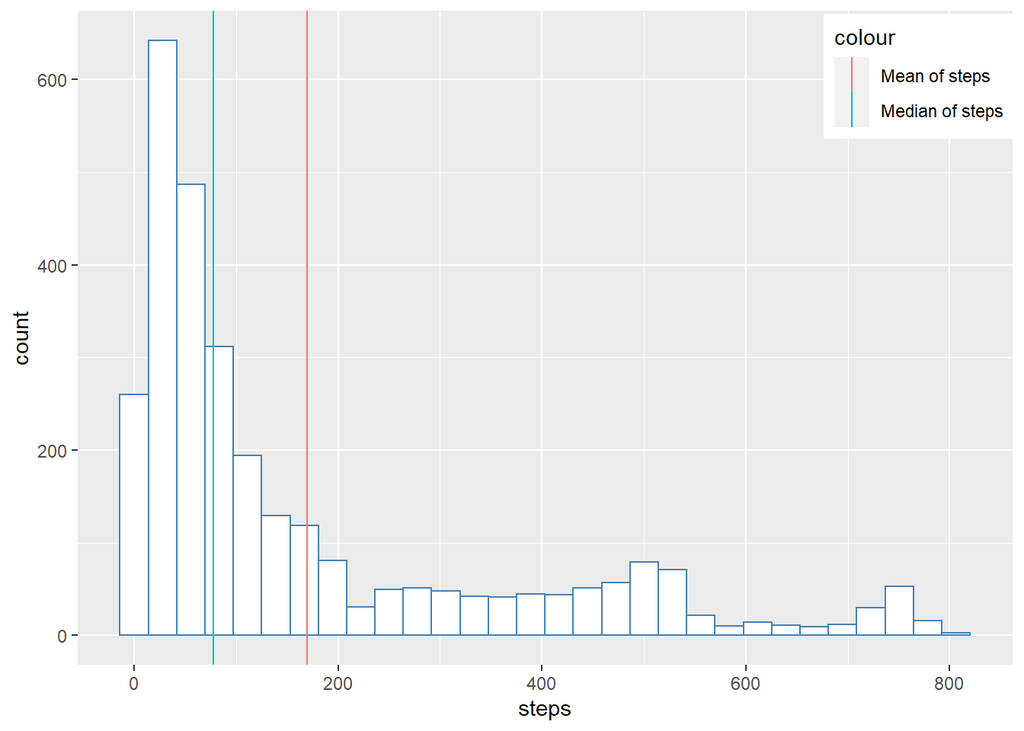

```r
no_NA %>%
        group_by(day, steps) %>%
        summarize(mean = mean(steps),
                  median = median(steps)) %>%
        ggplot(aes(x = steps)) +
        geom_histogram(fill="white", color = "steelblue", position="dodge") +
        geom_vline(aes(xintercept = mean(steps), color = "Mean of steps")) +
        geom_vline(aes(xintercept = median(steps), color = "Median of steps")) +
        theme(legend.position = c(0.9, 0.9))
```

## Are there differences in activity patterns between weekdays and weekends? 1. Create a new factor variable in the dataset with two levels – “weekday” and “weekend” indicating whether a given date is a weekday or weekend day.

```r
## Set language
Sys.setlocale("LC_ALL","English")
```

```
## [1] "LC_COLLATE=English_United States.1252;LC_CTYPE=English_United States.1252;LC_MONETARY=English_United States.1252;LC_NUMERIC=C;LC_TIME=English_United States.1252"
```

```r
activity_week <- activity %>%
        filter(!is.na(steps) | steps != 0, !is.na(interval)) %>%
        mutate(day = wday(date, label = TRUE, abbr = TRUE),
               Wday = ifelse(day == "Sun" | day == "Sat", "weekend", "weekday")) %>%
        group_by(interval, Wday) %>%
        summarize(avg = mean(steps, na.rm = TRUE))
```

2. Make a panel plot containing a time series plot (i.e. type = “l”) of the 5-minute interval (x-axis) and the average number of steps taken, averaged across all weekday days or weekend days (y-axis).

[figure not shown]

```r
ggplot(na.omit(activity_week), aes(x = interval, y = avg)) +
        geom_line(stat = "identity", color = "steelblue") +
        facet_wrap(Wday ~ .) +
        theme(plot.title = element_text(hjust = 0.5)) +
        labs(x = "Interval (sec.)",
             y = "Number of Steps",
             title = "Mean steps over each 5min interval split by weekday/weekend")
```